# **"Öğrenci Performansı" Veri Seti Üzerinde Python ile İstatistiki Analizler**

#### k. Devamsızlık Verilerinin Görselleştirilmesi

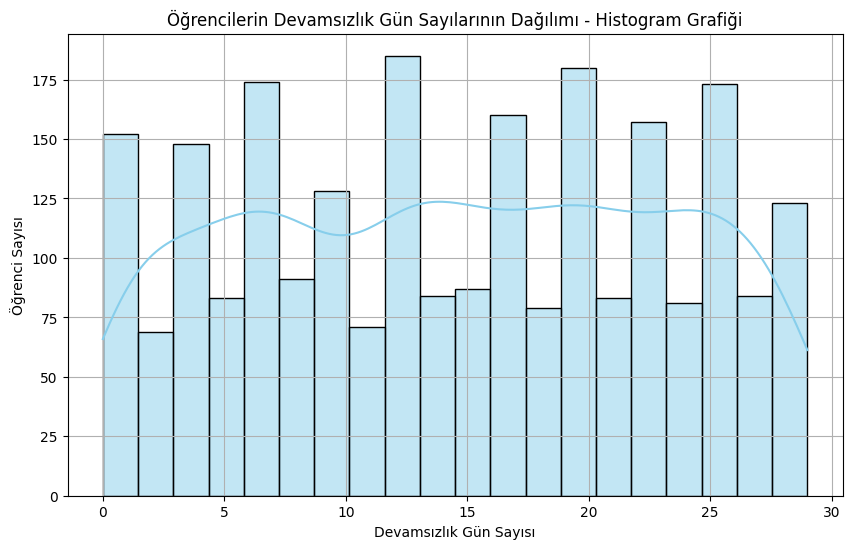

```python
plt.figure(figsize=(10, 6))
sns.histplot(data['Devamsızlık'], bins=20, kde=True, color='skyblue', edgecolor='black')
plt.title("Öğrencilerin Devamsızlık Gün Sayılarının Dağılımı - Histogram Grafiği")
plt.xlabel("Devamsızlık Gün Sayısı")
plt.ylabel("Öğrenci Sayısı")
plt.grid(True)
plt.show()
```

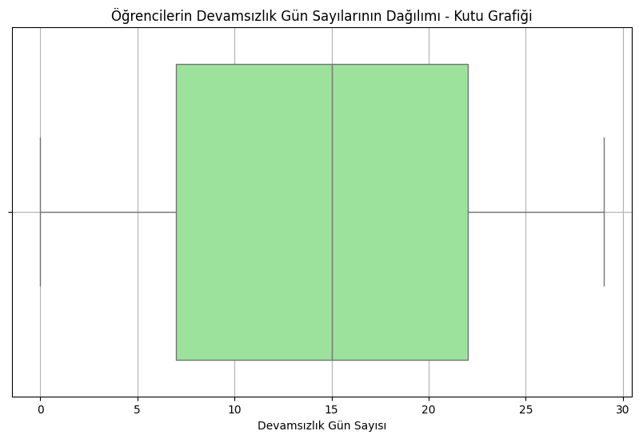

```python
plt.figure(figsize=(10, 6))
sns.boxplot(x=data['Devamsızlık'], color='lightgreen')
plt.title("Öğrencilerin Devamsızlık Gün Sayılarının Dağılımı - Kutu Grafiği")
plt.xlabel("Devamsızlık Gün Sayısı")
plt.grid(True)
plt.show()
```

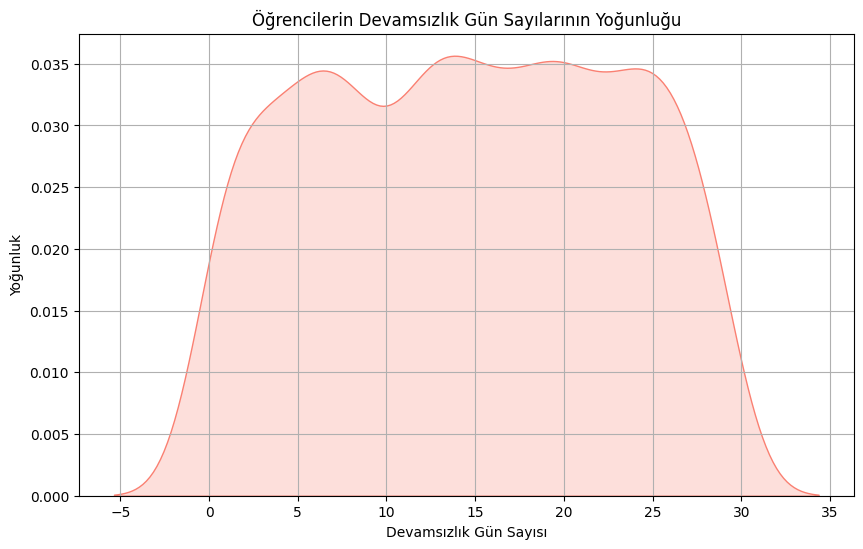

```python
plt.figure(figsize=(10, 6))
sns.kdeplot(data['Devamsızlık'], shade=True, color='salmon')
plt.title("Öğrencilerin Devamsızlık Gün Sayılarının Yoğunluğu")
plt.xlabel("Devamsızlık Gün Sayısı")
plt.ylabel("Yoğunluk")
plt.grid(True)
plt.show()
```

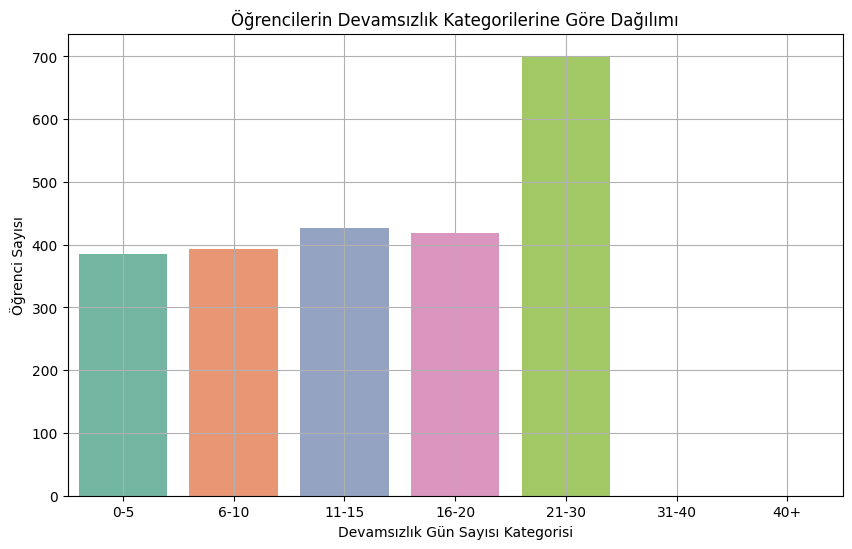

```python
# Devamsızlık verisini kategorilere ayıralım
bins = [0, 5, 10, 15, 20, 30, 40, 50]
labels = ['0-5', '6-10', '11-15', '16-20', '21-30', '31-40', '40+']
data['Devamsızlık_Kategori'] = pd.cut(data['Devamsızlık'], bins=bins, labels=labels)

# Sütun grafiği ile görselleştirme
plt.figure(figsize=(10, 6))
sns.countplot(x='Devamsızlık_Kategori', data=data, palette='Set2')
plt.title("Öğrencilerin Devamsızlık Kategorilerine Göre Dağılımı")
plt.xlabel("Devamsızlık Gün Sayısı Kategorisi")
plt.ylabel("Öğrenci Sayısı")
plt.grid(True)
plt.show()
```

#### l. Haftalık Ders Çalışma Süresi Verilerinin Görselleştirilmesi

```python
# HaftalikCalisma sütunundaki sayıları virgülden sonra 2 basamağa yuvarlayalım
data['HaftalikCalisma'] = data['HaftalikCalisma'].round(2)
```

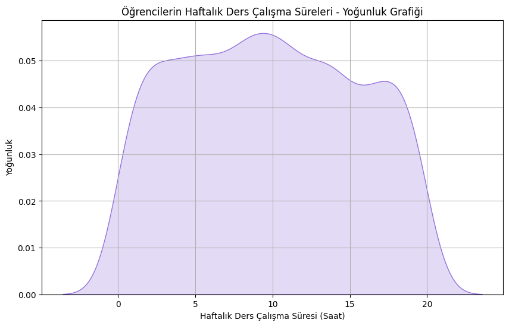

```python
plt.figure(figsize=(10, 6))
sns.kdeplot(data['HaftalikCalisma'], shade=True, color='mediumpurple')
plt.title("Öğrencilerin Haftalık Ders Çalışma Süreleri - Yoğunluk Grafiği")
plt.xlabel("Haftalık Ders Çalışma Süresi (Saat)")
plt.ylabel("Yoğunluk")
plt.grid(True)
plt.show()
```

#### m. GANO Verilerinin Görselleştirilmesi

```python
# GANO sütunundaki sayıları virgülden sonra 2 basamağa yuvarlayalım
data['GANO'] = data['GANO'].round(2)
```

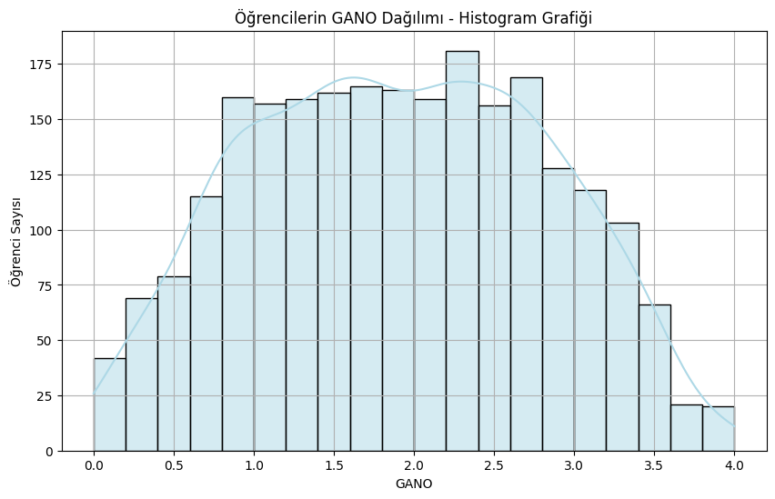

```python
plt.figure(figsize=(10, 6))
sns.histplot(data['GANO'], bins=20, kde=True, color='lightblue', edgecolor='black')
plt.title("Öğrencilerin GANO Dağılımı - Histogram Grafiği")
plt.xlabel("GANO")
plt.ylabel("Öğrenci Sayısı")
plt.grid(True)
plt.show()
```

#### n. Sınıf Seviyesi Verilerinin Görselleştirilmesi

[figure not shown]

```python
plt.figure(figsize=(10, 6))
data['Sınıf'].value_counts().sort_index().plot(
    kind='barh',
    color=sns.color_palette('muted'),
    edgecolor='black'
)
plt.title("Öğrencilerin Sınıf Düzeylerine Göre Dağılımı - Yatay Çubuk Grafiği")
plt.xlabel("Öğrenci Sayısı")
plt.ylabel("Sınıf Düzeyi")
plt.yticks([0, 1, 2, 3, 4], ['1. Sınıf', '2. Sınıf', '3. Sınıf', '4. Sınıf', 'Toplam'])
plt.grid(axis='x')
plt.show()
```

### **3. Veriler Arasında Korelasyon Analizi**

#### a. GANO Verisi ile Diğer Veriler Arasındaki İlişki

```python
target_variable = "GANO"               # Hedef değişken: GANO

correlation_results = {}

for column in data.columns[1:]:
    if data[column].dtype in [np.float64, np.int64] and column != target_variable:

        correlation, p_value = pearsonr(data[target_variable], data[column])                      # Pearson korelasyonunu ve p-değerini hesaplanması

        correlation_results[column] = {"Korelasyon": correlation, "P-Değeri": p_value}

correlation_df = pd.DataFrame.from_dict(correlation_results, orient='index')                      # Sonuçların DataFrame'e çevrilmesi ve sıralı olarak gösterilmesi
correlation_df = correlation_df.sort_values(by="Korelasyon", ascending=False)

display(correlation_df)
```

|  | Korelasyon | P-Değeri |
| --- | --- | --- |
| EbeveynDestegi | 0.190821 | 4.756147e-21 |
| HaftalikCalisma | 0.179193 | 1.037907e-18 |
| OzelDers | 0.145118 | 9.925778e-13 |
| MufredatDısı | 0.094140 | 3.986970e-06 |
| Muzik | 0.073197 | 3.398274e-04 |
| Spor | 0.057832 | 4.664445e-03 |
| Etnik | 0.027796 | 1.741488e-01 |
| Gonulluluk | 0.003368 | 8.692330e-01 |
| Yas | 0.000273 | 9.893395e-01 |
| Cinsiyet | -0.013445 | 5.110089e-01 |
| EbeynEgitim | -0.035758 | 8.037420e-02 |
| Sınıf | -0.782821 | 0.000000e+00 |
| Devamsızlık | -0.919302 | 0.000000e+00 |

#### b. GANO Verisi ile Diğer Veriler Arasındaki İlişkilerin Görselleştirilmesi

##### i. Korelasyon Matrisi (Heatmap)

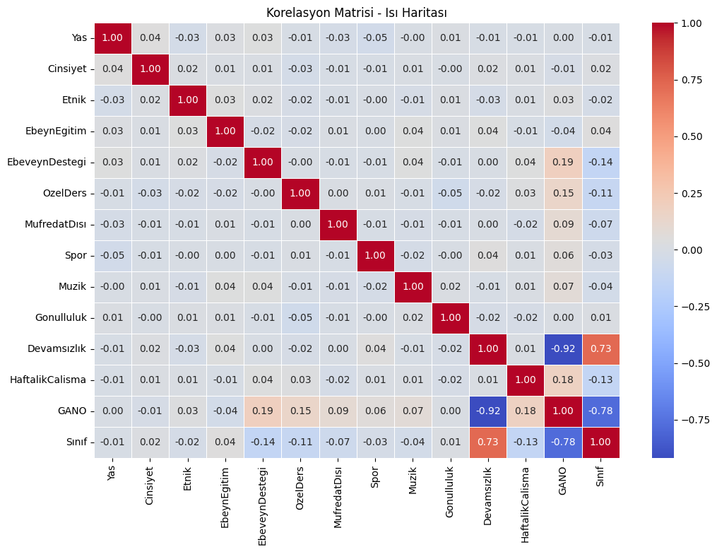

```python
numerical_data = data.select_dtypes(include=[np.number])
numerical_data = data.drop(columns=["OgrenciID"]).select_dtypes(include=[np.number])
plt.figure(figsize=(12, 8))  # Görsel boyutunu ayarla
sns.heatmap(numerical_data.corr(), annot=True, cmap="coolwarm", fmt=".2f", linewidths=0.5)
plt.title("Korelasyon Matrisi - Isı Haritası")
plt.show()
```

##### ii. Scatter Plot Grafikleri

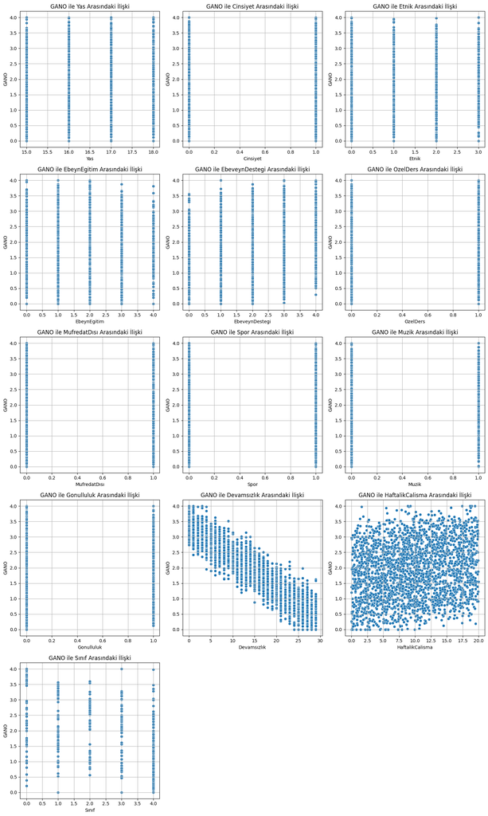

```python
# Hedef değişken
target_variable = "GANO"

numeric_columns = [
    column for column in data.select_dtypes(include=[np.float64, np.int64]).columns
    if column != target_variable and column != "OgrenciID"
]

# Izgara boyutunun belirlenmesi
ncols = 3
nrows = (len(numeric_columns) + ncols - 1) // ncols  # Satır sayısının hesaplanması

# Izgara düzeni
fig, axes = plt.subplots(nrows=nrows, ncols=ncols, figsize=(15, 5 * nrows))
axes = axes.flatten()  # Izgarayı tek boyutlu hale getir

# Scatter plot'ları çizilmesi
for i, column in enumerate(numeric_columns):
    sns.scatterplot(x=data[column], y=data[target_variable], ax=axes[i])
    axes[i].set_title(f"GANO ile {column} Arasındaki İlişki")
    axes[i].set_xlabel(column)
    axes[i].set_ylabel(target_variable)
    axes[i].grid(True)

# Boş eksenleri kaldırılması
for j in range(len(numeric_columns), len(axes)):
    fig.delaxes(axes[j])

plt.tight_layout()  # Grafikler arasında düzenli boşluk bırak
plt.show()
```

### **4. Çıkarımlar**

##### Bu korelasyon ve p-değer tablosu üzerinden bir analiz yapalım. Temel odak noktası, korelasyon katsayıları ve bunların istatistiksel anlamlılıklarının p-değerleri ile değerlendirilmesidir.

##### .

##### Korelasyon Katsayıları (Correlation)

##### Korelasyon katsayısı, iki değişken arasındaki doğrusal ilişkinin yönünü ve gücünü ifade eder:

##### .

##### **Pozitif Korelasyon:** Bir değişken arttığında diğerinin de artmasını ifade eder. (0 ile 1 arasında)

##### **Negatif Korelasyon:** Bir değişken arttığında diğerinin azalmasını ifade eder. (-1 ile 0 arasında)

##### **0'a Yakın:** İki değişken arasında anlamlı bir doğrusal ilişki olmadığını ifade eder.

##### p-değeri, elde edilen korelasyonun tesadüfi olup olmadığını test eder:

##### .

##### **p < 0.05:** Korelasyon istatistiksel olarak anlamlıdır.

##### **p > 0.05:** Korelasyon istatistiksel olarak anlamlı değildir (tesadüfen oluşmuş olabilir).

##### .

##### Detaylı Analiz

##### Tablodaki her değişkeni sırayla inceleyelim:

#### **1. Ebeveyn Desteği - GANO Analizi**

##### **Korelasyon:** 0.190 (zayıf pozitif ilişki)

##### **p-değeri:** Çok düşük (anlamlı)

##### **Sonuç:** Ebeveyn desteği ile başarı arasında zayıf bir pozitif ilişki var.

#### **2. Haftalık Çalışma - GANO**

##### **Korelasyon:** 0.179 (zayıf pozitif ilişki)

##### **p-değeri:** Çok düşük (anlamlı)

##### **Sonuç:** Haftalık çalışma ile başarı arasında zayıf bir pozitif ilişki var.

#### **3. Özel Ders - GANO**

##### **Korelasyon:** 0.145 (zayıf pozitif ilişki)

##### **p-değeri:** Çok düşük (anlamlı)

##### **Sonuç:** Özel ders almanın başarıya küçük bir katkısı var.

#### **4. Müfredat Dışı Aktiviteler - GANO**

##### **Korelasyon:** 0.094 (çok zayıf pozitif ilişki)

##### **p-değeri:** Çok düşük (anlamlı)

##### **Sonuç:** Müfredat dışı aktiviteler ile başarı arasında çok zayıf bir ilişki var.

#### **5. Müzik - GANO**

##### **Korelasyon:** 0.073 (çok zayıf pozitif ilişki)

##### **p-değeri:** Çok Düşük (anlamlı)

##### **Sonuç:** Müzik ile başarı arasında çok zayıf bir pozitif ilişki var.

#### **6. Spor - GANO**

##### **Korelasyon:** 0.058 (çok zayıf pozitif ilişki)

##### **p-değeri:** Çok Düşük (anlamlı)

##### **Sonuç:** Sporun başarıya etkisi minimal ancak pozitif yönde.

#### **7. Etnik Köken - GANO**

##### **Sonuç:** Etnik köken ile başarı arasında anlamlı bir ilişki yok.

#### **8. Gönüllülük - GANO**

##### **Sonuç:** Gönüllülük ile başarı arasında ilişki yok.

#### **9. Yaş - GANO**

##### **Sonuç:** Yaş ile başarı arasında bir ilişki yok.

#### **10. Cinsiyet - GANO**

##### **Sonuç:** Cinsiyetin ile başarı arasında bir ilişkisi yok.

#### **11. Ebeveyn Eğitimi - GANO**

##### **Sonuç:** Ebeveyn eğitimi ile başarı arasında zayıf bir negatif ilişki var ama anlamlı değil.

#### **12. Sınıf Seviyesi - GANO**

##### **Korelasyon:** -0.783 (çok güçlü negatif ilişki)

##### **p-değeri:** Güçlü (anlamlı)

##### **Sonuç:** Sınıf seviyesi arttıkça başarı düşüyor.

#### **13. Devamsızlık - GANO**

##### **Korelasyon:** -0.919 (çok güçlü negatif ilişki)

##### **p-değeri:** Güçlü (anlamlı)

##### **Sonuç:** Devamsızlık arttıkça başarı ciddi şekilde düşüyor.

#### **Genel Sonuçlar**

##### **En Güçlü İlişkiler**: Devamsızlık ve sınıf seviyesi ile başarı arasında güçlü negatif ilişkiler var.

##### **Zayıf Pozitif İlişkiler**: Ebeveyn desteği, haftalık çalışma gibi faktörler başarıya katkı sağlıyor ama etkisi sınırlı.

##### **Anlamsız Faktörler:** Etnik köken, gönüllülük, yaş ve cinsiyet gibi faktörler başarıyı etkilemiyor.

##### Bu analizle, başarıyı etkileyen faktörlerin belirginliği ve önceliklendirilmesi yapılabilir.